# Fitting LDA Models in R

Wouter van Atteveldt

February 13, 2018

Fitting LDA models in R is technically quite simple: just call the `LDA` function from the `topicmodels` package. First, let’s create a document term matrix from the inaugural speeches in quanteda, at the paragraph level since we can expect these to be mostly about the same topic:

```r
library(quanteda)
texts = corpus_reshape(data_corpus_inaugural, to = "paragraphs")
dfm = dfm(texts, remove_punct=T, remove=stopwords("english"))
dfm = dfm_trim(dfm, min_docfreq = 5)
```

To run LDA from a dfm, first convert to the topicmodels format, and then run LDA. Note the useof `set.seed(.)` to make sure that the analysis is reproducible.

```r
library(topicmodels)
dtm = convert(dfm, to = "topicmodels")
set.seed(1)
m = LDA(dtm, method = "Gibbs", k = 10,  control = list(alpha = 0.1))
m
```

```
## A LDA_Gibbs topic model with 10 topics.
```

## Inspecting LDA results

We can use `terms` to look at the top terms per topic:

```r
terms(m, 5)
```

| Topic 1 | Topic 2 | Topic 3 | Topic 4 | Topic 5 | Topic 6 | Topic 7 | Topic 8 | Topic 9 | Topic 10 |
| --- | --- | --- | --- | --- | --- | --- | --- | --- | --- |
| great | upon | government | us | can | nations | government | us | world | government |
| years | shall | people | god | every | peace | public | let | peace | shall |
| states | duties | states | day | america | war | business | can | freedom | congress |
| now | country | union | president | must | foreign | revenue | new | people | may |
| upon | people | every | new | country | united | can | must | free | law |

The `posterior` function gives the posterior distribution of words and documents to topics, which can be used to plot a word cloud of terms proportional to their occurrence:

```r
topic = 6
words = posterior(m)$terms[topic, ]
topwords = head(sort(words, decreasing = T), n=50)
head(topwords)
```

```
##    nations      peace        war    foreign     united     states
## 0.02084942 0.01905361 0.01779653 0.01582114 0.01564156 0.01312741
```

Now we can plot these words:

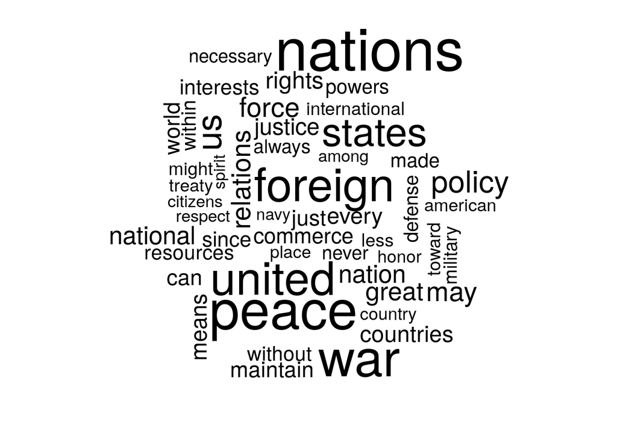

```r
library(wordcloud)
wordcloud(names(topwords), topwords)
```

We can also look at the topics per document, to find the top documents per topic:

```r
topic.docs = posterior(m)$topics[, topic]
topic.docs = sort(topic.docs, decreasing=T)
head(topic.docs)
```

```
##   1949-Truman.43 1805-Jefferson.3  1901-McKinley.2   1949-Truman.25
##        0.9181818        0.9093023        0.9050000        0.8882353
##   1813-Madison.7 1889-Harrison.22
##        0.8714286        0.8627907
```

And we can find this document in the original texts by looking up the document id in the document variables `docvars`:

```r
docs = docvars(dfm)
topdoc = names(topic.docs)[1]
docid = which(rownames(docs) == topdoc)
texts[docid]
```

```
##                                                                                                                                      1949-Truman.43
## "In addition, we will provide military advice and equipment to free nations which will cooperate with us in the maintenance of peace and security."
```

Finally, we can see which president prefered which topics:

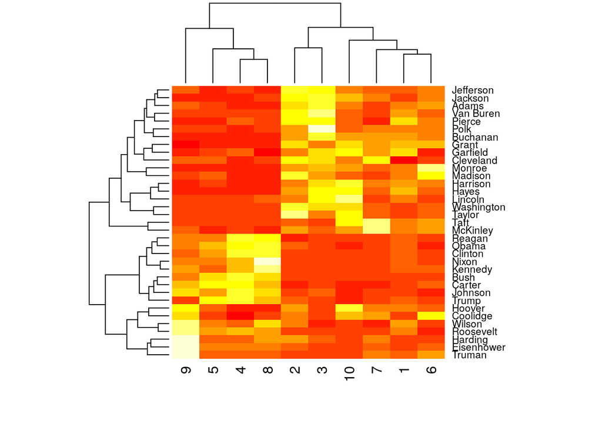

```r
docs = docs[rownames(docs) %in% rownames(dtm), ]
tpp = aggregate(posterior(m)$topics, by=docs["President"], mean)
rownames(tpp) = tpp$President
heatmap(as.matrix(tpp[-1]))
```

As you can see, the topics form a sort of ‘block’ distribution, with more modern presidents and older presidents using quite different topics. So, either the role of presidents changed, or language use changed, or (probably) both.

To get a better fit of such temporal dynamics, see the session on *structural topic models*, which allow you to condition topic proportions and/or contents on metadata covariates such as source or date.

## Visualizing LDA with LDAvis

`LDAvis` is a nice interactive visualization of LDA results. It needs the LDA and DTM information in a slightly different format than what’s readily available, but you can use the code below to create that format from the lda model `m` and the `dtm`:

```r
dtm = dtm[slam::row_sums(dtm) > 0, ]
phi = as.matrix(posterior(m)$terms)
theta <- as.matrix(posterior(m)$topics)
vocab <- colnames(phi)
doc.length = slam::row_sums(dtm)
term.freq = slam::col_sums(dtm)[match(vocab, colnames(dtm))]
library(LDAvis)
json = createJSON(phi = phi, theta = theta, vocab = vocab,
     doc.length = doc.length, term.frequency = term.freq)
serVis(json)
```